# Aula 1 - de Introdução ao R

Podemos passar as instruções no R diretamente no console, onde ele irá ler e processar a informação e retornar a resposta.

Fazendo 7 + 6 no console temos o retorno.

```r
7 + 6
```

```
[1] 13
```

Também podemos utilizar scripts. Para abrir um novo script, acesse o botão “+” à esquerda ou utilize o atalho Ctrl + Shift + N.

No script, escrevemos a instrução e pressionamos Ctrl + Enter para executá-la.

```r
2 + 7
```

```
[1] 9
```

Dentro do script podemos escrever instruções e comentários. 2 + 7 é uma instrução que será avaliada e reproduzirá o resultado.

```r
2 + 7
```

```
[1] 9
```

A hashtag (#) simboliza o comentário, logo será ignorado pelo operador. Mesmo que executemos a linha, o operador irá ignorar esta linha. Podemos fazer várias operações no R, como por exemplo:

Logaritmo na base 10: Calcula o logaritmo de um número na base 10.

```r
log10(100)
```

```
[1] 2
```

Comentários são muito importantes, devem informar sobre o trecho do código e serem diretos e instrutivos.

As instruções podem ocupar a linha inteira ou mais de uma linha:

```r
2 *
    12 *
    22 *
    53
```

```
[1] 27984
```

No prompt, os sinais de mais indicam continuidade. Identação: Ctrl + I

Até agora utilizamos o R como uma calculadora. Mas o interessante é utilizar o R para criar objetos e atribuir valores a esses objetos.

Objetos podem ser valores, textos, tabelas, gráficos, diretórios, etc. Ou seja, tudo que podemos guardar dentro de um nome. Para fazer atribuições no R podemos utilizar “<-” ou “=”.

Quando criamos uma variável no R não precisamos dizer o tipo de variável. O R irá alocar corretamente cada tipo de variável dinamicamente (tipagem dinâmica).

Podemos criar variáveis para calcular o IMC (Índice de Massa Corporal).

```r
imc
```

```
[1] 24.25128
```

Observe que as variáveis serão criadas no ambiente Global Environment.

Se tentarmos acessar uma variável que não foi criada, receberemos um erro.

```r
raio
```

```
Erro: objeto 'raio' não encontrado
```

Podemos listar as variáveis com o comando:

```r
ls()
```

```
 [1] "altura"             "draw.plotmath.cell" "draw.title.cell"    "get.c"
 [5] "get.r"              "i"                  "imc"                "make.table"
 [9] "nc"                 "nr"                 "oldpar"             "peso"
[13] "x"                  "xm"
```

```r
ls()  # Lista as variáveis restantes
```

```
 [1] "altura"             "draw.plotmath.cell" "draw.title.cell"    "get.c"
 [5] "get.r"              "i"                  "imc"                "make.table"
 [9] "nc"                 "nr"                 "oldpar"             "peso"
[13] "xm"
```

Diretórios no R

Verificar para onde o R está apontando:

```r
getwd()
```

```
[1] "C:/Users/p0131335/OneDrive/Desktop"
```

```r
dir()
```

```
 [1] "1 - ACERVO - 2017 A 2024 - 12-06-2024 (1).xlsx"
 [2] "15200d79ab404a26aa16ceccffa63783.png"
 [3] "4_ConsultaInformalAsPartes___Nome___Angelo_Furtado_da_Silva___23.07.24_para_envio.pdf"
 [4] "403_modelos_discretos_adicionais.pdf"
 [5] "Anaile - distribuidos - JESP BH.xls"
 [6] "Arquivos_CEJUR"
 [7] "arquivos_pessoais"
 [8] "brasilia.pdf"
 [9] "Comarcas_2.xlsx"
[10] "Cursos"
[11] "desktop.ini"
[12] "formulas_painel.txt"
[13] "hello.txt"
[14] "IEC"
[15] "Introducao_ao_R"
[16] "Lista_usuarios_por_setor_15.07.2024.xlsx"
[17] "Lista_usuarios_por_setor_17.07.2024.xlsx"
[18] "ME"
[19] "mensal_junho.pdf"
[20] "mensal_junho_Pagamento_pos.pdf"
[21] "metricas_indices_painel"
[22] "OperosidadeMagistrados.xls"
[23] "Pendencias - ME - IA.txt"
[24] "pHsArtM.xlsx"
[25] "Relacao_mandados_30dias_ref_09-06-24.xlsx"
[26] "segunda"
[27] "series"
[28] "Softwares"
[29] "Todos_municipios.xlsx"
[30] "Webex.lnk"
```

Quando instalamos o R, ele vem com poucos pacotes instalados. O poder do R está na quantidade de pacotes já disponíveis para os usuários. Podemos instalar pacotes via comando:

```r
install.packages('tidyverse') # necessário fazer uma única vez.
```

```
Error in install.packages : Updating loaded packages
```

Carregar o pacote, sempre que iniciarmos o R.

```r
library(tidyverse)
```

Também podemos instalar pacotes via interface do RStudio. Atualização de versão dos pacotes:

```r
update.packages()
```

```
Error in readRDS(dest) : erro ao ler a partir de conexão
```

Remover pacote:

```r
remove.packages('tidyverse')
```

```
Removing package from ‘C:/Users/p0131335/AppData/Local/R/win-library/4.3’
```

Diretório onde o pacote foi instalado:

```r
system.file(package = 'tidyverse') # Dentro desse caminho encontramos os arquivos do pacote.
```

```
[1] ""
```

```r
dir(system.file(package = 'tidyverse')) # São os arquivos que estão no diretório raiz desse pacote.
```

```
character(0)
```

Caminho que o R está procurando os pacotes:

```r
.libPaths()
```

```
[1] "C:/Users/p0131335/AppData/Local/R/win-library/4.3"
[2] "C:/Program Files/R/R-4.3.2/library"
```

Principais funções INICIANTES. Estrutura de objetos: Exibe a estrutura interna de um objeto.

```r
str(peso) # Exibe a estrutura da variável peso
```

```
Erro: objeto 'peso' não encontrado
```

Listar os objetos: Lista os objetos no ambiente atual.

```r
ls()
```

```
 [1] "draw.plotmath.cell" "draw.title.cell"    "get.c"              "get.r"
 [5] "i"                  "imc"                "make.table"         "nc"
 [9] "nr"                 "oldpar"             "xm"
```

Listar objetos com nome relacionado que está dentro da função: Procura objetos que contêm o padrão especificado.

```r
apropos("peso") # Procura objetos que contêm "peso" no nome
```

```
character(0)
```

Ajuda da função ou pacote: Abre a documentação de ajuda de uma função ou pacote.

```r
help("tidyverse")# Documentação do pacote tidyverse
```

```
No documentation for ‘tidyverse’ in specified packages and libraries:
you could try ‘??tidyverse’
```

Abre a página inicial de procura para que possamos navegar do zero.

```r
help.start()
```

```
If nothing happens, you should open
‘http://127.0.0.1:21209/doc/html/index.html’ yourself
```

Busca por palavra no site: Pesquisa no site do R por uma palavra-chave.

```r
RSiteSearch("mean")     # Pesquisa por "mean" no site do R
```

```
A search query has been submitted to https://search.r-project.org
A página de resultados deverá abrir no seu navegador em breve
```

Vai procurar as vinhetas que o pacote tem: Exibe uma lista de vinhetas disponíveis.

```r
browseVignettes("tidyverse") # Lista de vinhetas do pacote tidyverse
```

Caso o usuário saiba o nome da vinheta, você pode abrir ela automaticamente.

```r
vignette("tidyverse")        # Abre a vinheta "tidyverse"
```

Quais os argumentos das funções que posso modificar: Mostra os argumentos de uma função.

```r
args(lm)     # Argumentos da função lm
```

```
function (formula, data, subset, weights, na.action, method = "qr",
    model = TRUE, x = FALSE, y = FALSE, qr = TRUE, singular.ok = TRUE,
    contrasts = NULL, offset, ...)
NULL
```

Classe do objeto: Mostra a classe de um objeto.

```r
class(altura) # Classe da variável altura
```

```
Erro: objeto 'altura' não encontrado
```

De acordo com a classe do objeto teremos um método específico.

```r
methods(class = "matrix") # Métodos para a classe matrix
```

```
 [1] anyDuplicated as.data.frame as.raster     as_tibble     boxplot       coerce        determinant
 [8] duplicated    edit          head          initialize    isSymmetric   Math          Math2
[15] Ops           relist        subset        summary       tail          unique
see '?methods' for accessing help and source code
```

A partir do nome de objeto ele irá retornar o pacote que esse objeto está definido.

```r
find("lm")     # Encontra o pacote que define a função lm
```

```
[1] "package:stats"
```

Na documentação do pacote temos a sessão exemplos. Esses dois comandos são para rodar esses exemplos.

```
lm> require(graphics)

lm> ## Annette Dobson (1990) "An Introduction to Generalized Linear Models".
lm> ## Page 9: Plant Weight Data.
lm> ctl <- c(4.17,5.58,5.18,6.11,4.50,4.61,5.17,4.53,5.33,5.14)

lm> trt <- c(4.81,4.17,4.41,3.59,5.87,3.83,6.03,4.89,4.32,4.69)

lm> group <- gl(2, 10, 20, labels = c("Ctl","Trt"))

lm> weight <- c(ctl, trt)

lm> lm.D9 <- lm(weight ~ group)

lm> lm.D90 <- lm(weight ~ group - 1) # omitting intercept

lm> ## No test:
lm> anova(lm.D9)
Analysis of Variance Table

Response: weight
          Df Sum Sq Mean Sq F value Pr(>F)
group      1 0.6882 0.68820  1.4191  0.249
Residuals 18 8.7292 0.48496

lm> summary(lm.D90)

Call:
lm(formula = weight ~ group - 1)

Residuals:
    Min      1Q  Median      3Q     Max
-1.0710 -0.4938  0.0685  0.2462  1.3690

Coefficients:
         Estimate Std. Error t value Pr(>|t|)
groupCtl   5.0320     0.2202   22.85 9.55e-15 ***
groupTrt   4.6610     0.2202   21.16 3.62e-14 ***
---
Signif. codes:  0 ‘***’ 0.001 ‘**’ 0.01 ‘*’ 0.05 ‘.’ 0.1 ‘ ’ 1
```

[output cut: 8 more lines]

```

lm> plot(lm.D9, las = 1)      # Residuals, Fitted, ...

lm> par(opar)

lm> ## Don't show:
lm> ## model frame :
lm> stopifnot(identical(lm(weight ~ group, method = "model.frame"),
lm+                     model.frame(lm.D9)))

lm> ## End(Don't show)
lm> ### less simple examples in "See Also" above
lm>
lm>
lm>
```

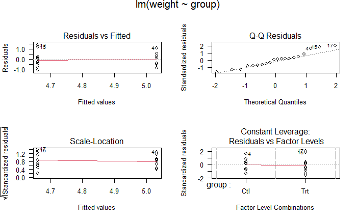

```r
example(lm)    # Exemplo de uso da função lm
```

[output not shown]

[output cut: 87 more lines]

```

> draw.plotmath.cell(expression(italic(x)), i, nr); i <- i + 1

> draw.plotmath.cell(expression(bold(x)), i, nr); i <- i + 1

> draw.plotmath.cell(expression(bolditalic(x)), i, nr); i <- i + 1

> draw.plotmath.cell(expression(underline(x)), i, nr); i <- i + 1

> # Need fewer, wider columns for ellipsis ...
> nr <- 20

> nc <- 2

> make.table(nr, nc)
```

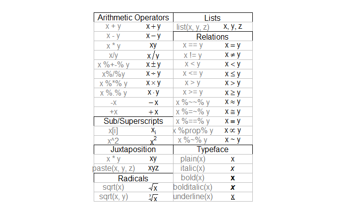

[output not shown]

[output cut: 40 more lines]

```

> draw.plotmath.cell(expression(infinity), i, nr); i <- i + 1

> draw.plotmath.cell(expression(32 * degree), i, nr); i <- i + 1

> draw.plotmath.cell(expression(60 * minute), i, nr); i <- i + 1

> draw.plotmath.cell(expression(30 * second), i, nr); i <- i + 1

> # Need even fewer, wider columns for typeface and style ...
> nr <- 20

> nc <- 1

> make.table(nr, nc)
```

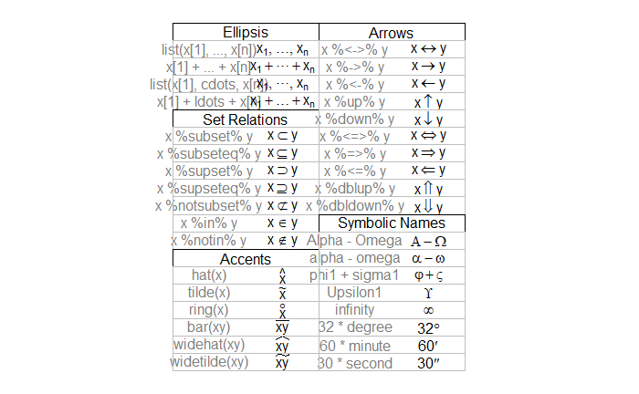

[output not shown]

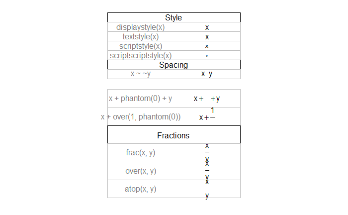

[output not shown]

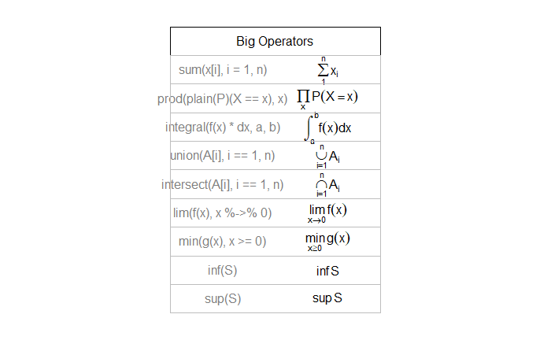

[output not shown]

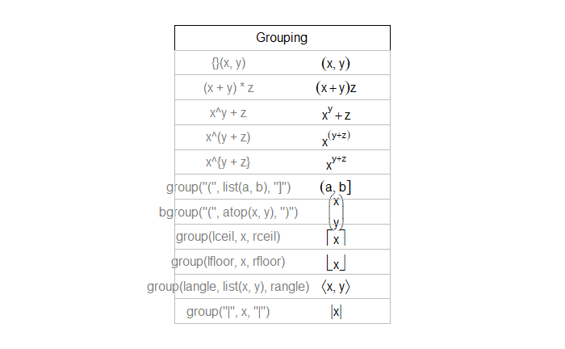

```r
demo("plotmath") # Mostra como os operadores podem ser inseridos nos gráficos.
```